# frame expansion

# Measuring frame expansion and calculating gantry factor

## Data functions

### Data import

I’ve written a little function to import the data and calculate the effective z distance from the raw step output.

```r
load_data <- function(data_fp, step_distance=0.0025) {
  data_df <- read.csv(data_fp, sep=',', comment.char = '#')

  data_df$z = (data_df$mcu_pos_z - data_df$mcu_pos_z[1])*step_distance
  return(data_df)
}
```

### Fitting model

Currently, alchemyEngine is calculating gantry correction factor by removing the beginning and end of the data, where changes to bed temperature seem to influence the estimated home location. (It’s thought that this is due to thermal changes in the homing microswitch itself, due to the proximity of the switch to the bed.)

As such, the module is really only effective at correcting tool Z positioning if it homes *after* the z switch has achieved thermal equilibrium. I was curious to see whether we could achieve a similar result by fitting the whole dataset as an additive effect of bed temperature and frame temperature.

This function takes the imported data and fits a simple additive linear model, including both bed and frame temperature as explanatory variables. It outputs a data structure with the fit model, the original data frame with columns added for the residuals and model fit predicted values, and a plot of the residuals.

```r
fit_model <- function(data_df) {
  mod <- lm(z ~ bed_t + frame_t, data_df)
  data_df$resid <- mod$residuals
  data_df$fit <- mod$fitted.values

  p <- ggplot(data_df, aes(x = fit, y = resid, color=sample)) + geom_point() + scale_color_viridis_c()
  return(list("data" = data_df,"model" = mod, "plot" = p))
}
```

## Dataset 1

This is the first run on my machine. Here, I’m using a 50K B3950 NTC thermistor for frame temp measurement, and defining it in Klipper using the `beta` parameter.

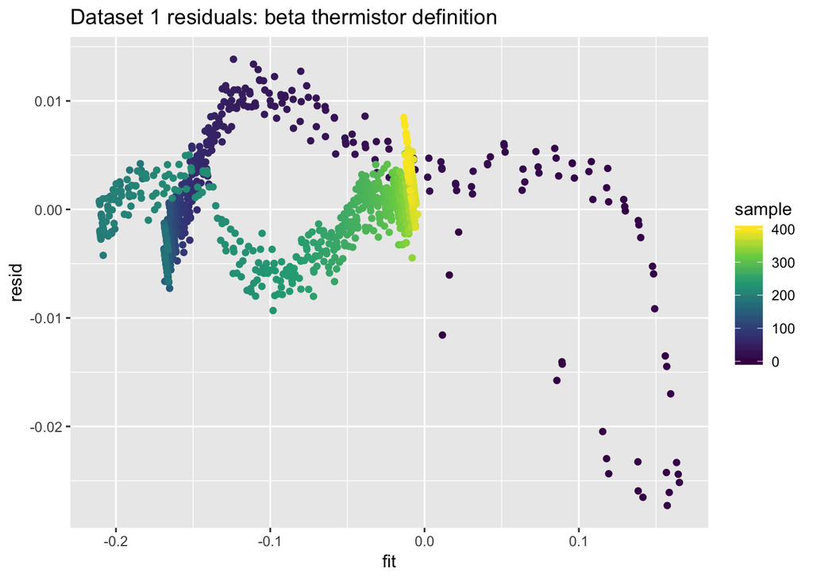

```r
df1 <- load_data('./data/frame_exp_quant_v3_2021-06-13_05-41-53.csv')
df1_mod <- fit_model(df1)

df1_mod$plot + ggtitle("Dataset 1 residuals: beta thermistor definition")
```

The residuals plot for this dataset shows that there’s some definite nonlinearity, as well as some lurking explanatory factors. However, the simple two-factor linear model explains 99.6% of the variance in the *total* dataset – about the same as what bed temperature alone explains in just the middle portion, per alchemyEngine’s calculations.

```r
summary(df1_mod$model)
```

```
##
## Call:
## lm(formula = z ~ bed_t + frame_t, data = data_df)
##
## Residuals:
##        Min         1Q     Median         3Q        Max
## -0.0272895 -0.0026938  0.0001583  0.0024089  0.0138406
##
## Coefficients:
##               Estimate Std. Error t value Pr(>|t|)
## (Intercept)  6.953e-01  1.480e-03   469.8   <2e-16 ***
## bed_t        2.003e-03  7.648e-06   261.9   <2e-16 ***
## frame_t     -3.335e-02  6.882e-05  -484.7   <2e-16 ***
## ---
## Signif. codes:  0 '***' 0.001 '**' 0.01 '*' 0.05 '.' 0.1 ' ' 1
##
## Residual standard error: 0.004843 on 1200 degrees of freedom
## Multiple R-squared:  0.9964, Adjusted R-squared:  0.9963
## F-statistic: 1.638e+05 on 2 and 1200 DF,  p-value: < 2.2e-16
```

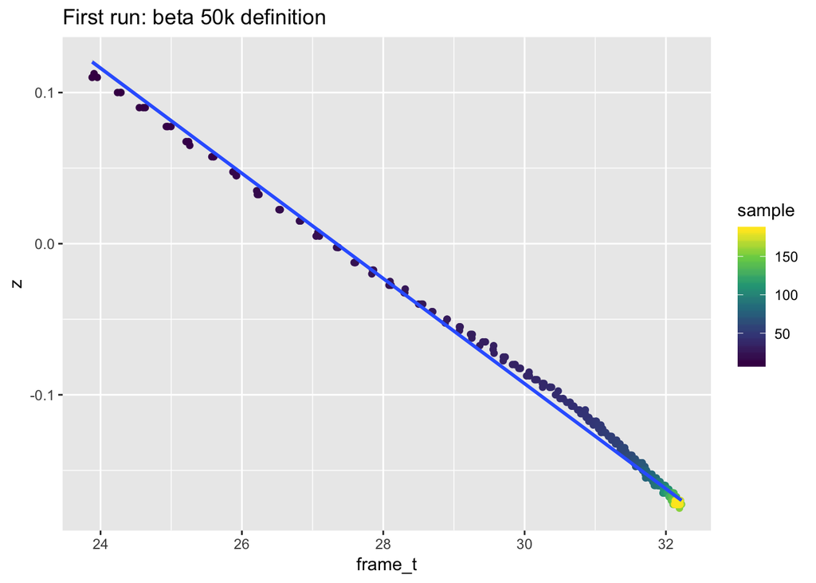

```r
l <- ggplot(subset(df1_mod$data, bed_target == 105 & sample>10), aes(x = frame_t, y = z, color=sample)) + geom_point() + scale_color_viridis_c() + geom_smooth(method=lm) + ggtitle('First run: beta 50k definition')

l
```

If we cut out just the portion of the dataset after the first 10 minutes and before the bed powers down, we can see that we’re not observing a very linear change in Z deviation with frame temperature. That is *not* what we’d expect if our model of frame expansion driving the Z deviation was accurate, as the frame should be expanding linearly with temperature! But maybe there’s something more going on…

## Dataset 1b

After some discussion about how thermistors are handled in Klipper, I decided to re-do the data collection using a three-point thermistor definition rather than the beta value. Otherwise, everything else about this dataset is identical.

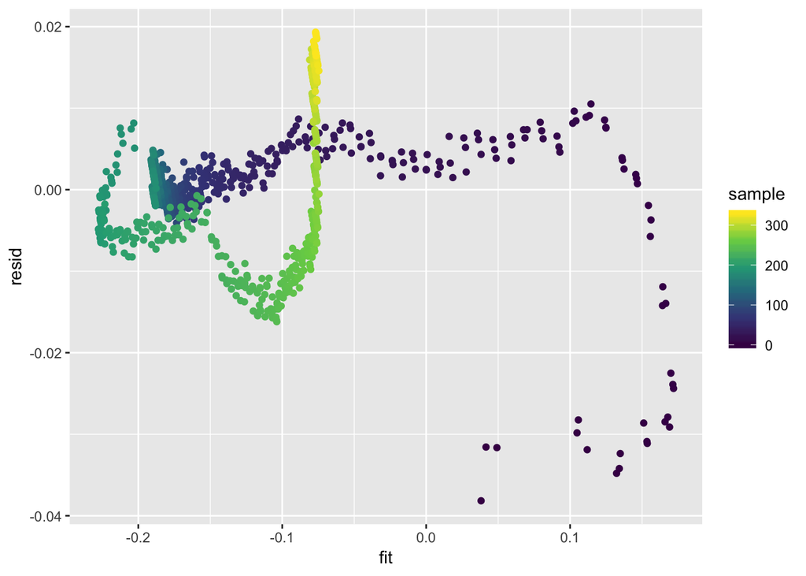

```r
df1b <- load_data('./data/expansion_quant_whoppingpochard#2514_2021-06-13_20-04-43.csv')
df1b_mod <- fit_model(df1b)

df1b_mod$plot
```

So this is interesting – the portion of the data immediate after the first warm-up period, and prior to the bed cooldown, seems to be very well predicted by our two-component model (the residuals are mostly hovering around zero, with much less of an apparent trend). There’s still something about the behavior after the bed powers down that we’re not capturing with these two measurements, though.

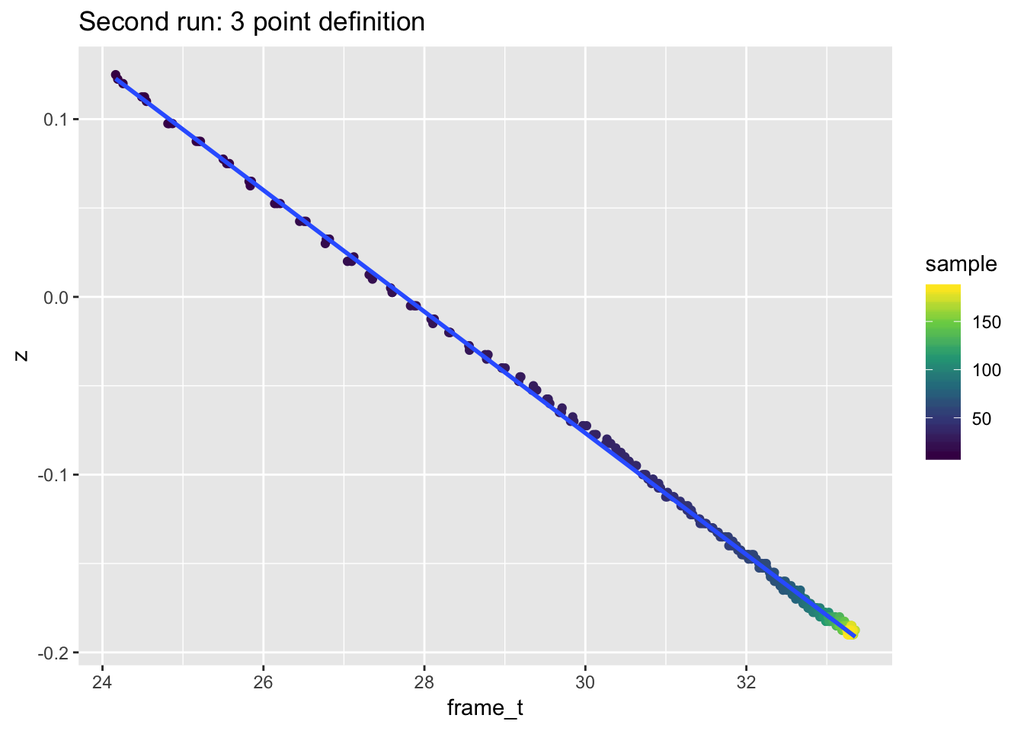

```r
ggplot(subset(df1b_mod$data, bed_target == 105 & sample>10), aes(x = frame_t, y = z, color=sample)) + geom_point() + scale_color_viridis_c() + geom_smooth(method=lm) + ggtitle('Second run: 3 point definition')
```

Looking at the central portion of the data now, we can see that this is *much* better fit by a linear model. This suggests that it really was error in how measured resistance was being converted to temperature leading to the nonlinearity, and our overall model of the system is still useful!

# Calculating gantry factor

Next, we’ll use the results to calculate the gantry factor that best fits my machine.

I’ve made a little helper function, adapted from the frame_compensation code, to reproduce the frame compensation factor that is calculated when it’s running on the machine. I’ve included my frame Z length and coefficient as defaults, but if you’re running this you’ll want to replace them with your own.

```r
calc_offset <- function(delta_t, frame_z=530/1E3, coeff=23.4/1E6, gantry_factor=1) {

  offset = -1 * (frame_z * (coeff * delta_t) * gantry_factor) * 1E3
  return(offset)
}
```

To actually estimate the gantry factor, we need to add another data column for the delta_t value between the timepoint we’re establishing as our reference, and the current timepoint. Then we can calculate the frame_comp offset for that delta_t.

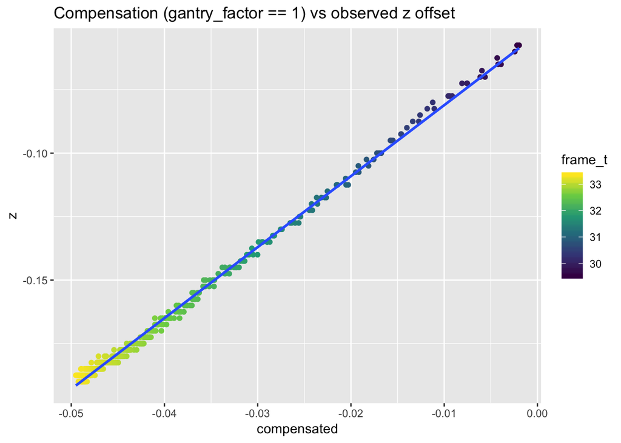

```r
test_df <- df1b_mod$data
test_df$delta_t <- test_df$frame_t - mean(test_df[test_df$sample == 30, 'frame_t'])
test_df$compensated <- unlist(lapply(test_df$delta_t, calc_offset))



ggplot(subset(test_df, bed_target == 105 & sample>30), aes(x = compensated, y = z, color=frame_t)) + geom_point() + geom_smooth(method=lm) + scale_color_viridis_c() + ggtitle('Compensation (gantry_factor == 1) vs observed z offset')
```

Plotting the offset we calculate given `gantry_factor == 1` shows us that, if we were to use 1 as our factor, klipper would only drop the toolhead about 0.018 mm when the Z was actually offset from -0.05 to -0.10 mm, so we actually want a `gantry_factor` about `0.05 / 0.018` times that, or around 2.8.

That is to say, the slope of the best-fit line equals the *actual* gantry factor we want to use:

```r
result <- lm(z ~ compensated, subset(test_df, bed_target == 105 & sample>30))
result
```

```
##
## Call:
## lm(formula = z ~ compensated, data = subset(test_df, bed_target ==
##     105 & sample > 30))
##
## Coefficients:
## (Intercept)  compensated
##    -0.05314      2.79613
```

Thus, going forward, I am using a `gantry_factor` of 2.8 for testing.